# Z- test

A z-test is a statistical test used to determine whether two population means

are different when the variances are known and the sample size is large

Assumption :

```
1.sample size is greater than 30.

2.Data points should be Independent from each other.

3.Data Should be normally distributed.

4.Population mean and Population variance is known.
```

# Basic of Z test

Statistical Fromula :

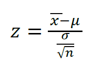

x_bar= Sample Mean

μ = Population Mean

σ = Population standard deviation

n = Sample Size

# One sample Z test :

The one sample Z test used when we want to know whether our sample comes from a particular population. Thus ,our hypothesis tests wheather the avarage of our sample suggests that our students come from a population with known mean or wheather it comes from a different population.

**Example**: To check the hight of the U.S.male population .currently the population mean is about 70 inches with a standard deviation of 3 inches.A total of 30 representative samples are taken and the height is measured.

**Hypothesis** :

H0 : μ=70

```
vs
```

H1 : μ≠70

```python
x=[67,70,65,73,71,72,69,73,71,72,73,71,71,67,67,69,66,68,65,66,73,68,67,73,71,70,75,68,73,66] # sample data
n=len(x)


μ=70                     #  Mean height|(inches) of U.S Males
σ=3                      # population Stndard Deviation
```

Test statistics is : Z=(x_bar-Mu)/ (std_dev/sqrt(n))

1. we have to find X_bar of sample , what is X_bar, X_bar is sample Mean .
2. we have use two methods to find sample mean or any mean a)using basic formaula and b) define the function for that

```python
#a)Basic Formula:

x_bar=sum(x)/len(x)
x_bar

# b) define the function mean:

def mean(data):
    y=sum(data)/len(data)
    return y
mean(x)
```

```
69.66666666666667
```

# Calculating Test Statistics :

```python
import math                   #import math function for using mathematical operation

z=(mean(x)-μ)/(σ/math.sqrt(n))
cal_value=z

print('cal_value :',cal_value)
```

```
cal_value : -0.6085806194501759
```

For that we have to import scipy.stats library

## Calulating Tabulated Value :

scipy.stats.norm.ppf(1-α)

where, α = Level of Significance

```python
import scipy.stats
tab_value=scipy.stats.norm.ppf(1-(0.05))
print('tab_value :',tab_value)
```

```
tab_value : 1.6448536269514722
```

## Conclusion :

```python
if tab_value > cal_value:
    print("Accept the Null hypothesis:\n" ," μ=70 ")
else:
    print("Reject the Null hypothesis:\n","μ≠70")
```

```
Accept the Null hypothesis:
  μ=70
```

# Two Sample Z-test :

The Two-sample Z-test is used to compare the means of two samples to see if it is feasible that they come from the same population.

Example : To compare the height of two male popualtions from the united states and sweden, a sample of 30 males from each country is randomly selected and the measured heights are provided. Mean,μ1=69.98 μ2=70.43 Standared Deviation ,σ1=3.12,σ2=2.44

```python
x1=[69.12,66.88,74.82,67,69.12,65,71,66.76,72.12,72.94,69.18,66.18,64.94,71.76,70.12,71,71.88,65.24,70.06,71.94,72.12,66.88,
    73.82,74,71.18,67.88,65.94,68.88,68,75.12]
n1=len(x1)
x2=[74.56,71.89,73,67.78,72.22,68,73.56,75,68.22,69,68,72,73.56,72.56,75,68.33,71.67,72.44,75,71.89,72,70,69.22,74.44,68,
    73.89,70,70.44,70.22,73.33]
n2=len(x2)

μ1=69.98
μ2=70.43
σ1=3.12
σ2=2.44
```

**Hypothesis** :

```python
H0:μ1-μ2=0     #μ1 : mean height of US male population & μ2 : mean height of Swedish male population
    vs

H1:μ1-μ2≠0
```

Test statistics is : S=((mean(x1)-mean(x2))-(Mu1-Mu2))/math.sqrt(((std_dev(x1)**2)/n1)+((std_dev(x2)**2)/n2))

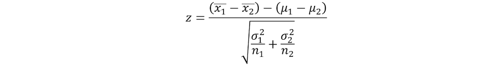

```python
def mean(data):
    y=sum(data)/len(data)
    return y
print(mean(x1))
print(mean(x2))
```

```
69.69600000000001
71.50733333333334
```

# Calculating Test Statistics :

```python
import math                   #import math function for using mathematical operation
def Ztest(x1,x2,σ1,σ2,Mu1,Mu2):
    s=((mean(x1)-mean(x2))-(μ1-μ2))/math.sqrt(((σ1**2)/n1)+((σ2**2)/n2))
    return s
Ztest(x1,x2,σ1,σ2,μ1,μ2)
cal_value= Ztest(x1,x2,σ1,σ2,μ1,μ2)
print('cal_value:',cal_value)
```

```
cal_value: -1.8825274420170446
```

# Calulating Tabulated Value :

scipy.stats.norm.ppf(1-α/2)

where, α/2 = Level of Significance

```python
import scipy.stats
tab_value=scipy.stats.norm.ppf(1-(0.05/2))
print('tab_value :',tab_value)
```

```
tab_value : 1.959963984540054
```

# Conclusion :

```python
if tab_value > cal_value:
    print("Accept the Null hypothesis:\n" ," μ1-μ2=0 ")
else:
    print("Reject the Null hypothesis:\n","μ1-μ2≠0")
```

```
Accept the Null hypothesis:
  μ1-μ2=0
```